# Lab 11 - Local regression and splines

Nonparametric statistics ay 2023/2024

2023/11/9

## Loading necessary libraries

```r
library(ISLR2)
library(car)
library(np)
library(splines)
library(fda)
library(magrittr)
library(KernSmooth)
```

## Nonparametric Regression (cont.)

During the last lab we have familiarized with the two simplest ways to move beyond linearity in (univariate) regression, namely with polynomial and step functions. In this lab, we will look at two more methods that provide non-linear fitting: local regression and splines. While the former relies on local fitting (as the name suggests), splines will allow to merge together polynomial and step functions providing a powerful linear smoother.

## Local regression

Local regression involves computing the fit at a target point $x_0$ using only the **nearby** training observations. Local regression is sometimes referred to as a *memory-based* procedure because, like nearest-neighbors, we need all the training data each time we wish to compute a prediction. Let us keep working with the Prestige dataset. We start with weighted local averaging with uniform (or rectangular) kernel.

Recall that the general form of the kernel estimator is the following:

$$\hat{f}(x) = \hat{y}|x_0 = \frac{\sum_{i=1}^N w_i y_i}{\sum_{i=1}^N w_i}$$
where the weights $w_i$ are given by:
$$w_i = K(z_i) = K\big(\frac{x_i-x_0}{h}\big) \;\,\; i \in \{1, ..., N\}$$
and $K$ is the kernel function.

In the case of the uniform kernel, we have (see the [documentation, p. 11](https://cran.r-project.org/web/packages/np/np.pdf))
$$K_{uniform}(z) = \mathbb{1}_{\{|z| < 1\}}(z), \; h > 0$$

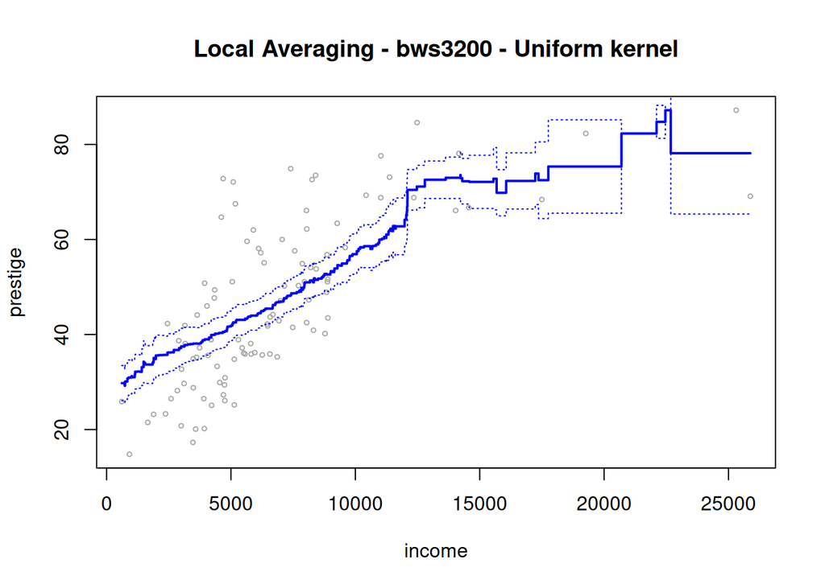

```r
m_loc = npreg(prestige ~ income,
              ckertype = 'uniform',
              bws = 3200, # bandwidth
              data = Prestige)

income_newdata <- data.frame(income=with(Prestige,
                                      seq(range(income)[1],range(income)[2],by=0.5))
                  )

preds <- predict(m_loc,newdata=income_newdata,se=T)
se.bands <- cbind(preds$fit +2* preds$se.fit ,preds$fit -2* preds$se.fit)
with(
  Prestige,
  plot(
    income ,
    prestige ,
    xlim = range(income_newdata$income) ,
    cex = .5,
    col = " darkgrey ",
    main = 'Local Averaging - bws3200 - Uniform kernel'
  )
)
lines(income_newdata$income,preds$fit ,lwd =2, col =" blue")
matlines(income_newdata$income,se.bands ,lwd =1, col =" blue",lty =3)
```

This can be manually implemented in a straightforward way. Spoiler alert: the code below is very bad in terms of efficiency and portability, it is only shown for didactic purposes!

```r
# we use a 'vectorised' function, which we can apply to a vector
loc_pred_unif_manual <- Vectorize(function(x_0, bw) {

  # indices of sample elements within the bandwidth
  ind_unit_in_bw <-
    which(Prestige$income > (x_0 - bw) & Prestige$income < (x_0 + bw))
  ind_unit_in_bw_alt <- which(abs((Prestige$income - x_0)/bw) <= 1)
  all.equal(ind_unit_in_bw, ind_unit_in_bw_alt) # TRUE

  Prestige %>%
    dplyr::slice(ind_unit_in_bw) %>%  # obtain only indices in bandwidth
    dplyr::summarise(mean(prestige)) %>%  # obtain the mean of prestige
    dplyr::pull()  # extract value

}, vectorize.args = "x_0")


# Predict original data

preds <- predict(m_loc, newdata=data.frame(income=Prestige$income))

# call the vectorised function
all(dplyr::near(preds, loc_pred_unif_manual(x_0 = Prestige$income,bw = 3200), tol = 1e-13))
```

```
## [1] TRUE
```

Let us try to decrease the bandwidth

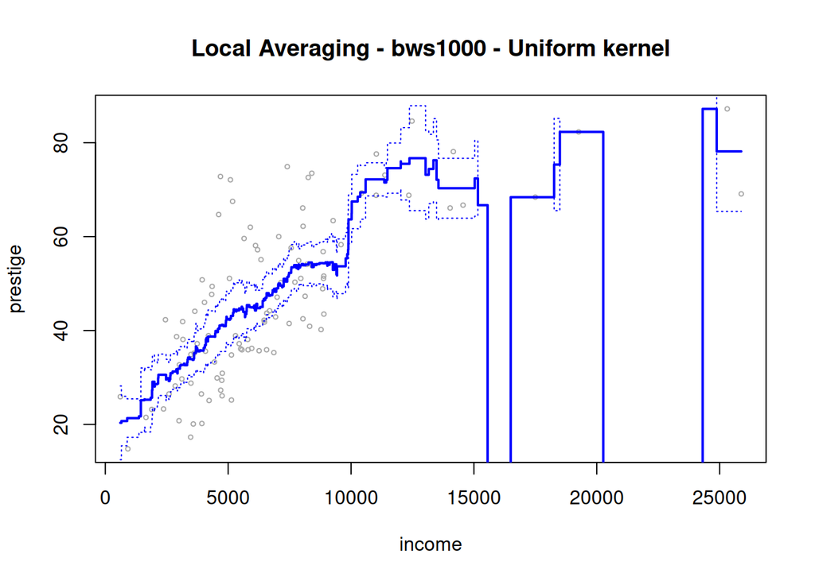

```r
m_loc = npreg(prestige ~ income,
              ckertype = 'uniform',
              bws = 1000, # bandwidth
              data = Prestige)

income_newdata=data.frame(income=with(Prestige, seq(range(income)[1],range(income)[2],by=0.5)))
preds=predict(m_loc,newdata=income_newdata,se=T)
se.bands=cbind(preds$fit +2* preds$se.fit ,preds$fit -2* preds$se.fit)
with(
  Prestige,
  plot(
    income ,
    prestige ,
    xlim = range(income_newdata$income) ,
    cex = .5,
    col = " darkgrey ",
    main = 'Local Averaging - bws1000 - Uniform kernel'
  )
)
lines(income_newdata$income,preds$fit ,lwd =2, col =" blue")
matlines(income_newdata$income,se.bands ,lwd =1, col =" blue",lty =3)
```

We have issues with uniform kernel if there are no data in the bins…

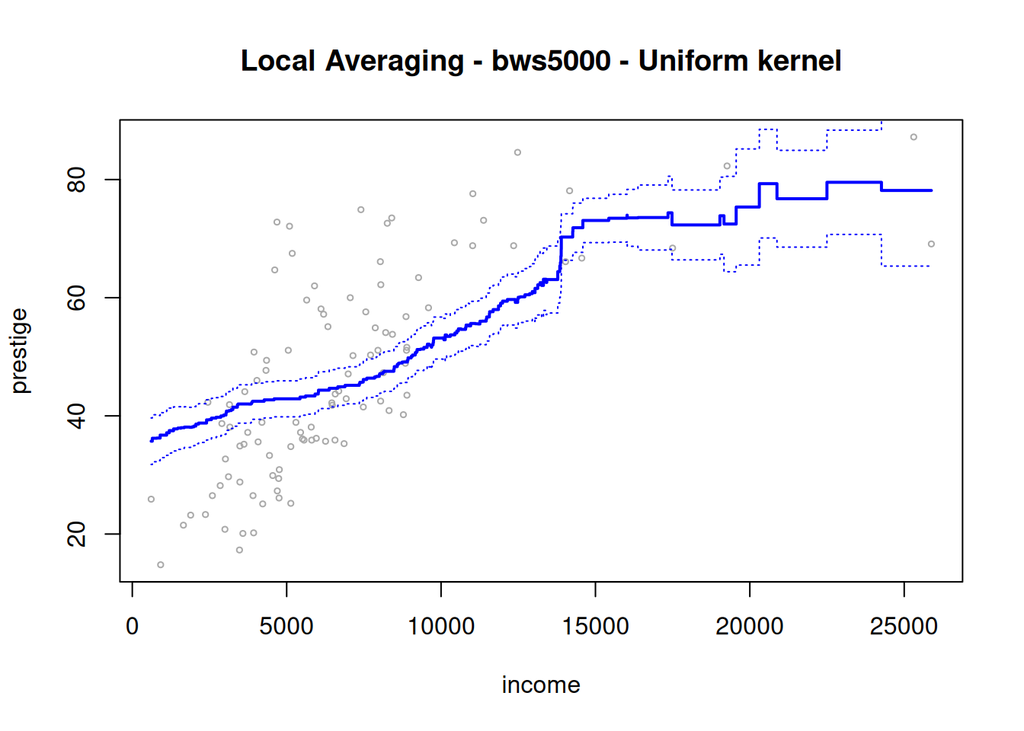

```r
m_loc = npreg(prestige ~ income,
              ckertype = 'uniform',
              bws = 5000, # bandwidth
              data = Prestige)

income_newdata=data.frame(income=with(Prestige, seq(range(income)[1],range(income)[2],by=0.5)))
preds=predict(m_loc,newdata=income_newdata,se=T)
se.bands=cbind(preds$fit +2* preds$se.fit ,preds$fit -2* preds$se.fit)
with(
  Prestige,
  plot(
    income ,
    prestige ,
    xlim = range(income_newdata$income) ,
    cex = .5,
    col = " darkgrey ",
    main = 'Local Averaging - bws5000 - Uniform kernel'
  )
)
lines(income_newdata$income,preds$fit ,lwd =2, col =" blue")
matlines(income_newdata$income,se.bands ,lwd =1, col =" blue",lty =3)
```

We could try a gaussian kernel:
$$K_{gaussian}(z_i) = \exp\bigg(\frac{z_i^2}{2}\bigg) =
\exp\bigg(\frac{1}{2}(\frac{x_i-x_0}{h})^2\bigg)$$

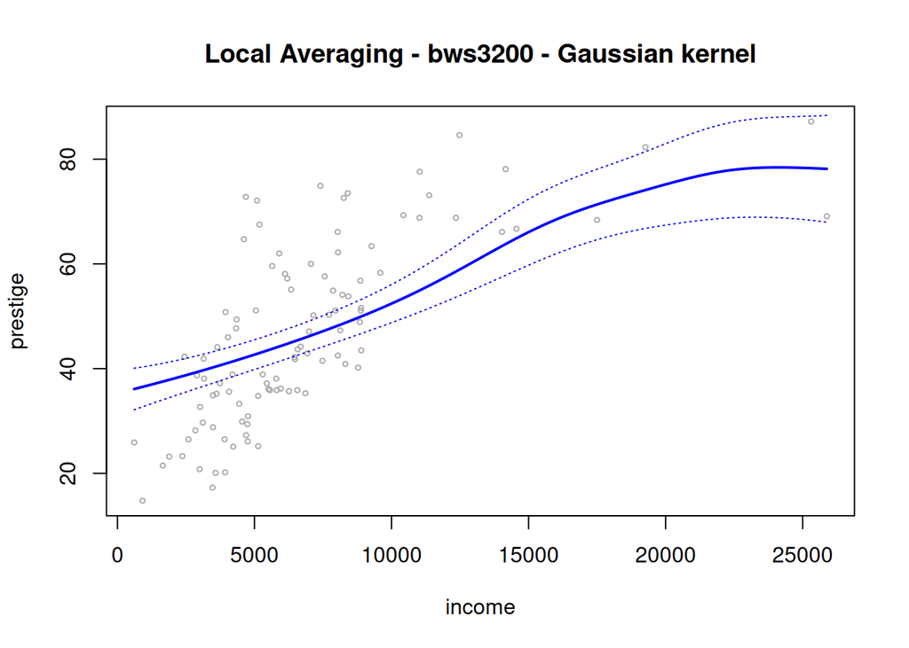

```r
m_loc = npreg(prestige ~ income,
              ckertype = 'gaussian',
              bws = 3200, # bandwidth
              data = Prestige)

income_newdata=data.frame(income=with(Prestige, seq(range(income)[1],range(income)[2],by=0.5)))
preds=predict(m_loc,newdata=income_newdata,se=T)
se.bands=cbind(preds$fit +2* preds$se.fit ,preds$fit -2* preds$se.fit)
with(
  Prestige,
  plot(
    income ,
    prestige ,
    xlim = range(income_newdata$income) ,
    cex = .5,
    col = " darkgrey ",
    main = 'Local Averaging - bws3200 - Gaussian kernel'
  )
)
lines(income_newdata$income,preds$fit ,lwd =2, col =" blue")
matlines(income_newdata$income,se.bands ,lwd =1, col =" blue",lty =3)
```

Several R packages provide implementations of local polynomial estimators. For instance, notice that the same results could be achieved by means of the `locpoly` function in the `KernSmooth` package:

```r
m_kern_smooth <- with(Prestige,KernSmooth::locpoly(x = income, y = prestige, bandwidth = 3200, degree = 0,
                           range.x = c(range(income)[1], range(income)[2]), gridsize = nrow(income_newdata)))

all(dplyr::near(m_kern_smooth$y,preds$fit,tol = 1e-1)) # somewhat different approx up to .1
```

```
## [1] TRUE
```

Furthermore, also the built-in `loess` function can be used for local polynomial regression fitting. Contrarily to `locpoly` and `npreg`, `loess` has a different control of the bandwidth by means of the span argument, defining the proportion of points of the sample that are taken into account for performing the local fit. Additionally, `loess` uses a triweight kernel for weighting the points contributions:
$$K_{triweight}(z(\alpha)) = \mathbb{1}_{\{|z|\leq1\}} (1-|z^3|)^2$$
where
$$z = z(\alpha) = \frac{x_i-x_0}{h(\alpha)}, \alpha \in (0,1)$$
where the bandwidth $h$ is a function of the span $\alpha$.

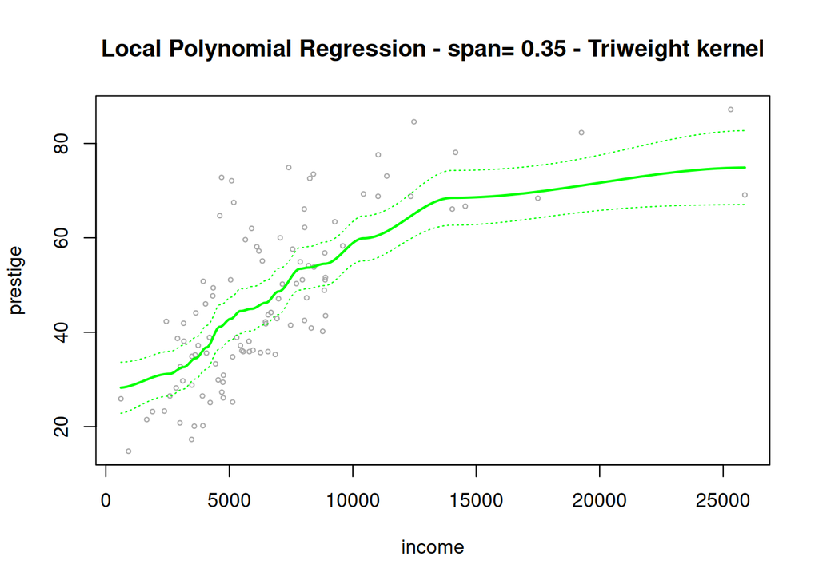

```r
m_loess = loess(prestige ~ income,
                span = .35,
                degree=0,  # becomes Nadaraya-Watson estimator
              data = Prestige)
preds_loess=predict(m_loess,newdata=income_newdata,se=T)
se.bands_loess=cbind(preds_loess$fit +2* preds_loess$se.fit ,preds_loess$fit -2* preds_loess$se.fit)
with(
  Prestige,
  plot(
    income ,
    prestige ,
    xlim = range(income_newdata$income) ,
    cex = .5,
    col = " darkgrey ",
    main = 'Local Polynomial Regression - span= 0.35 - Triweight kernel'
  )
)
lines(income_newdata$income,preds_loess$fit ,lwd =2, col =" green")
matlines(income_newdata$income,se.bands_loess ,lwd =1, col =" green",lty =3)
```

Last note: both `locpoly` and `loess` have a degree argument that allows us to control the degree of local polynomial used in the estimation. In the previous examples we have always relied on local constant fitting setting `degree=0` (also known as the Nadaraya–Watson estimator), but polynomial with higher degrees can be used. If you want to have a very nice interactive visualization on how local regression works you can check the following [link](https://bookdown.org/egarpor/PM-UC3M/npreg-kre.html#npreg-kre-locpoly) (Figure 6.6).

**Remark**: Utilising `loess` with `degree` higher than 0 we obtain *ipso facto* a **local polynomial**.

### Exercise

Try to perform again the analysis employing the last continuous kernel type available in the `np` package, namely the Epanechnikov kernel. Do the results change much with respect to the Gaussian kernel?

## Part II: Splines

### Piecewise Polynomial functions (towards local estimates)

Splines are piecewise polynomial functions which are constrained to join smoothly at knots. Nevertheless, before looking at splines let us empirically motivate their need by considering piecewise polynomials first.

Let us keep working with our Prestige dataset. Let us hard-code a piecewise polynomial with discontinuity at the chosen cutoff (hereafter called **knot**).

Recall that for knot $c$, the piecewise polynomial estimator is defined as:
$$y_i = \beta_{01} + \beta_{11}x_i + \beta_{21}x_i^2 + ... + \epsilon_i ,
\; x_i \leq c\\
y_i = \beta_{02} + \beta_{12}x_i + \beta_{22}x_i^2 + ... + \epsilon_i ,
\; x_i > c$$

```r
cutoff <- 10000
Prestige$income_cut <- Prestige$income>cutoff

Prestige$income_cut_model <- (Prestige$income - cutoff)*Prestige$income_cut

model_cut_disc=lm(prestige ~ income + income_cut_model + I(income>cutoff), data=Prestige)
# model_cut_disc=lm(prestige ~ 1 + income + income_cut_model + I(income>cutoff), data=Prestige) equivalent

model_cut_disc_alt =lm(prestige ~ 1+ income * income_cut, data=Prestige) # equivalent formulation

new_data <-
  with(Prestige, data.frame(
    income = seq(range(income)[1], range(income)[2], by = 0.5)
  ))

new_data$income_cut_model = (new_data$income - cutoff) * (new_data$income > cutoff)
new_data$income_cut = new_data$income > cutoff

preds = predict(model_cut_disc,new_data ,se=T)
preds.alt <- predict(model_cut_disc_alt, new_data, se=T)
all.equal(preds, preds.alt) # indeed they are true
```

```
## [1] TRUE
```

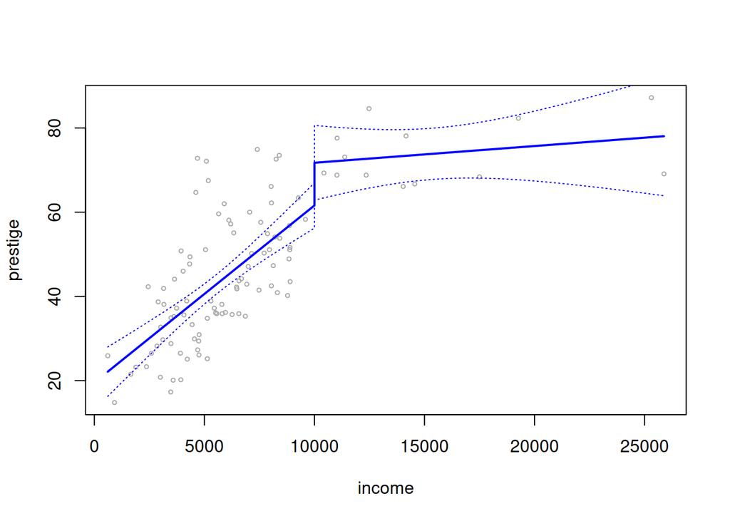

```r
se.bands=cbind(preds$fit +2* preds$se.fit ,preds$fit -2* preds$se.fit)

with(Prestige, plot(income ,prestige ,xlim=range(new_data$income) ,cex =.5, col =" darkgrey " ))
lines(new_data$income,preds$fit ,lwd =2, col =" blue")
matlines(new_data$income, se.bands ,lwd =1, col =" blue",lty =3)
```

We can easily consider polynomials that go beyond the first degree:

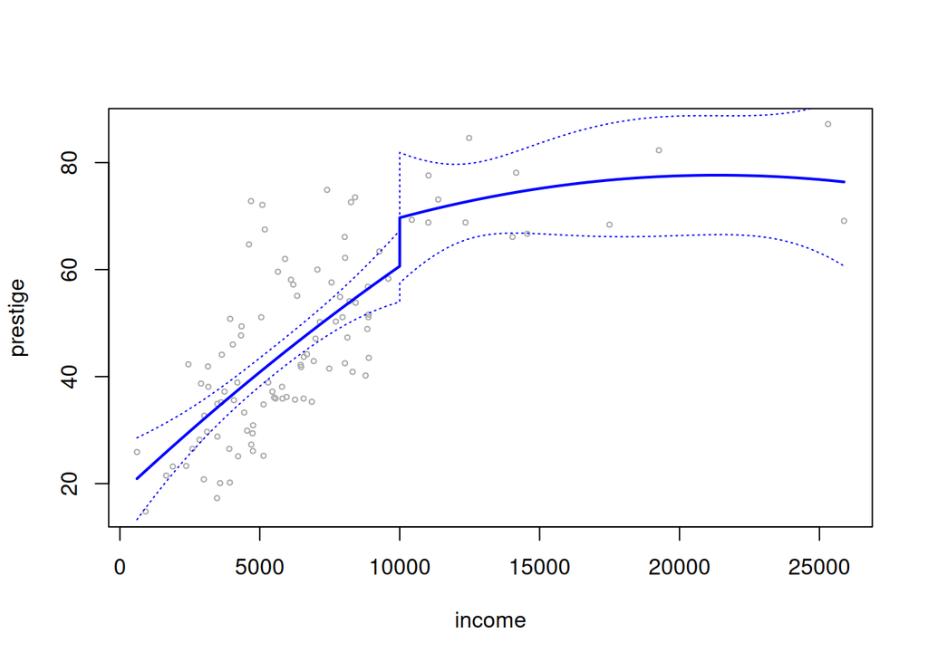

```r
model_cut_quad <- lm(prestige ~ poly(income,degree = 2) + income_cut_model + I(income>cutoff),  data=Prestige)
preds=predict(model_cut_quad,new_data,se=T)
se.bands=cbind(preds$fit +2* preds$se.fit ,preds$fit -2* preds$se.fit)

with(Prestige, plot(income ,prestige ,xlim=range(new_data$income) ,cex =.5, col =" darkgrey " ))
lines(new_data$income,preds$fit ,lwd =2, col =" blue")
matlines(new_data$income, se.bands ,lwd =1, col =" blue",lty =3)
```

This indeed gives us a lot of flexibility, yet you can feel that having discontinuities in the estimated regression line may not be ideal… We can force the regression line to be continuous by dropping the `I(income>cutoff)` term in the `model_cut_disc` model, thus getting back a degree of freedom:

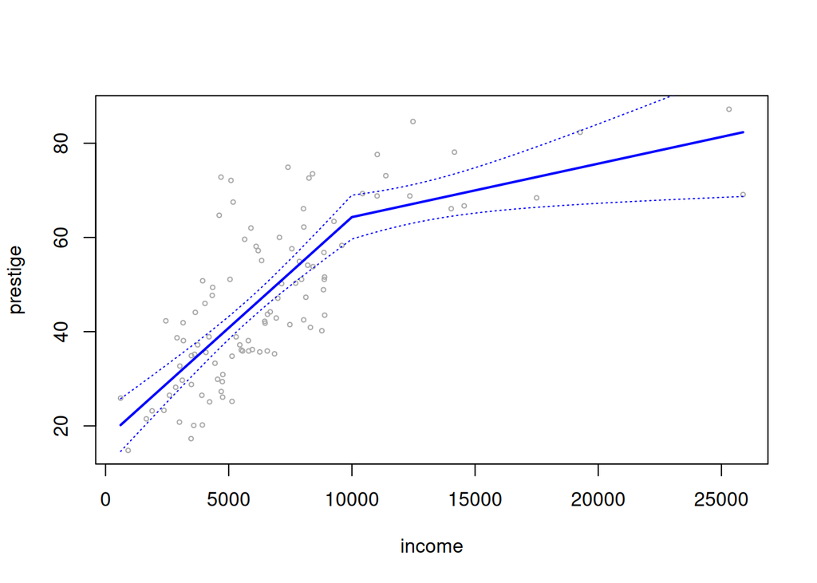

```r
model_cut=lm(prestige ~ income + income_cut_model, data=Prestige)
preds_cut=predict(model_cut,new_data ,se=T)
se.bands_cut=cbind(preds_cut$fit +2* preds_cut$se.fit ,preds_cut$fit -2* preds_cut$se.fit)
with(Prestige, plot(income ,prestige ,xlim=range(new_data$income) ,cex =.5, col =" darkgrey " ))
lines(new_data$income,preds_cut$fit ,lwd =2, col =" blue")
matlines(new_data$income, se.bands_cut ,lwd =1, col =" blue",lty =3)
```

We have manually fitted our first piece-wise linear spline with one knot at $x=10000$! How to move forward in this direction? That is, allowing for different functional forms in different bins whilst maintaining some degree of smoothness in the interpolation? We can effectively do so by employing the built-in `splines` package. The idea underlying regression splines relies on:

1. Specification of a set of knots
2. producing sequence of basis functions (yields design matrix)
3. Using least squares for estimating coefficients.

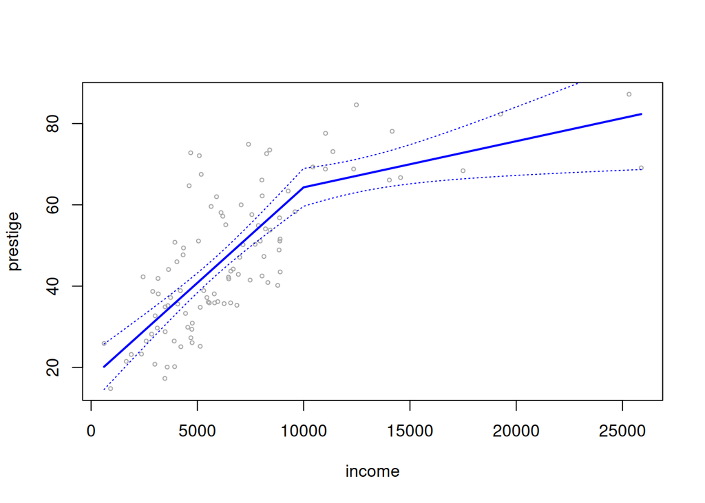

```r
model_linear_spline <- lm(prestige ~ bs(income, knots=c(10000),degree=1), data=Prestige)

preds=predict(model_linear_spline,new_data,se=T)
se.bands=cbind(preds$fit +2* preds$se.fit ,preds$fit -2* preds$se.fit)

with(Prestige, plot(income ,prestige ,xlim=range(new_data$income) ,cex =.5, col =" darkgrey " ))
lines(new_data$income,preds$fit ,lwd =2, col =" blue")
matlines(new_data$income, se.bands ,lwd =1, col =" blue",lty =3)
```

Recall that we can always look at the design matrix (and how the `bs()` command builds the polynomial splines) with the `model.matrix()` function

```r
head(unname(model.matrix(model_linear_spline)))
```

```
##      [,1]      [,2]       [,3]
## [1,]    1 0.8519428 0.14805718
## [2,]    1 0.0000000 1.00000000
## [3,]    1 0.9223559 0.00000000
## [4,]    1 0.8791139 0.00000000
## [5,]    1 0.8299073 0.00000000
## [6,]    1 0.9351345 0.06486555
```

Notice that predictions made with the hard-coded `model_cut` model is the same as the `model_linear_spline` one:

```r
all(dplyr::near(x = preds_cut$fit,preds$fit))
```

```
## [1] TRUE
```

Yet, the model coefficients are different:

```r
rbind(model_cut=coef(model_cut),
model_linear_spline=coef(model_linear_spline))
```

```
##                     (Intercept)       income income_cut_model
## model_cut              17.30643  0.004700415     -0.003565982
## model_linear_spline    20.17838 44.132196319     62.145854931
```

The reason is due to the different *bases* used to represent the space of spline functions: the former employs a conceptually simple (and easy to code) truncated power basis, whereas the latter uses a **computationally more efficient B-spline basis** (more on this later in the lab).

Flexibility? The sky is the limit here. Let us build a piecewise linear spline

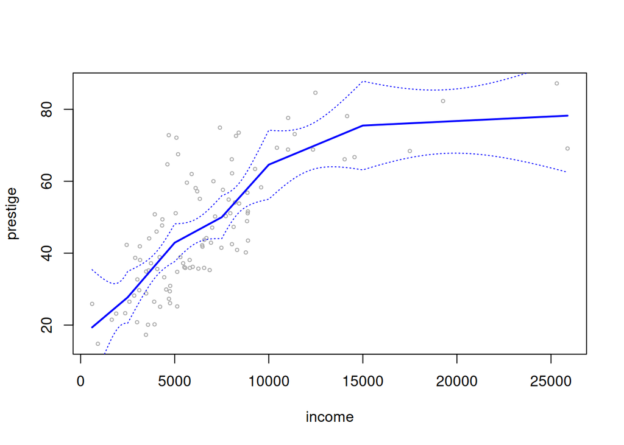

```r
inc_breaks <- c(seq(0, 10000, by = 2500)[-1], 15000)

model_linear_spline_2 <-
  lm(prestige ~ bs(income, knots = inc_breaks, degree = 1), data = Prestige)

preds=predict(model_linear_spline_2, new_data,se=T)
se.bands=cbind(preds$fit +2* preds$se.fit ,preds$fit -2* preds$se.fit)

with(Prestige, plot(income ,prestige ,xlim=range(new_data$income) ,cex =.5, col =" darkgrey " ))
lines(new_data$income,preds$fit ,lwd =2, col =" blue")
matlines(new_data$income, se.bands ,lwd =1, col =" blue",lty =3)
```

Piecewise quadratic

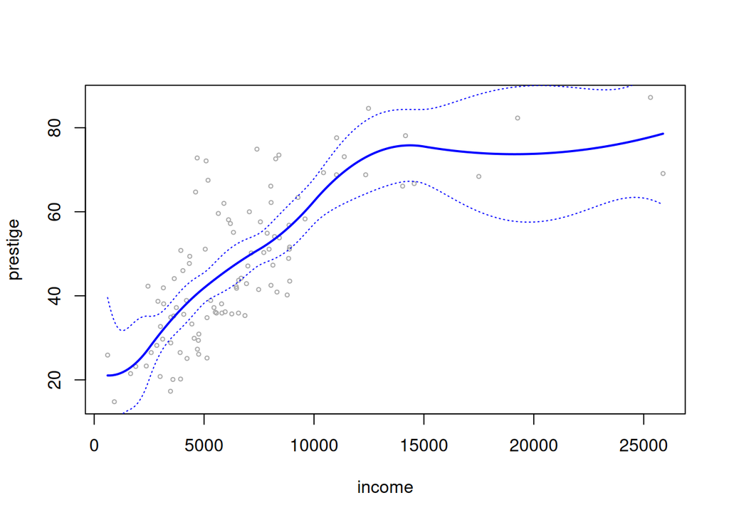

```r
model_quad_splines <-
  lm(prestige ~ bs(income, knots = inc_breaks, degree = 2), data = Prestige)

preds=predict(model_quad_splines, new_data,se=T)
se.bands=cbind(preds$fit +2* preds$se.fit ,preds$fit -2* preds$se.fit)

with(Prestige, plot(income ,prestige ,xlim=range(new_data$income) ,cex =.5, col =" darkgrey " ))
lines(new_data$income,preds$fit ,lwd =2, col =" blue")
matlines(new_data$income, se.bands ,lwd =1, col =" blue",lty =3)
```

Cubic spline

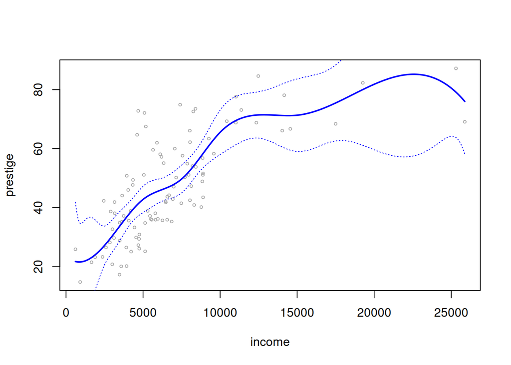

```r
model_cubic_splines <-
  lm(prestige ~ bs(income, knots = inc_breaks, degree = 3), data = Prestige)

preds=predict(model_cubic_splines, new_data,se=T)
se.bands=cbind(preds$fit +2* preds$se.fit ,preds$fit -2* preds$se.fit)

with(Prestige, plot(income ,prestige ,xlim=range(new_data$income) ,cex =.5, col =" darkgrey " ))
lines(new_data$income,preds$fit ,lwd =2, col =" blue")
matlines(new_data$income, se.bands ,lwd =1, col =" blue",lty =3)
```

I can either specify the knots (as done so far), or have R automatically select the spacing, I just need to specify their number knowing that:
$$dof = \#knots +
degree$$

Example: if we want $4$ knots and a cubic spline, we will end up with $7$ degrees of freedom.

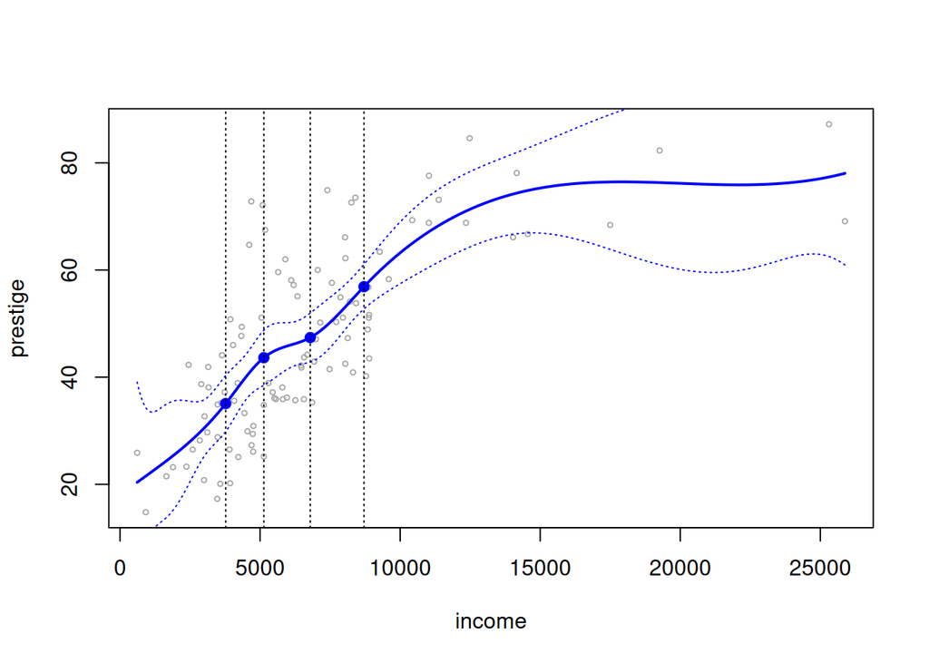

```r
model_cubic_splines_2 <-
    lm(prestige ~ bs(income, degree = 3,df = 7), data = Prestige)

preds=predict(model_cubic_splines_2, new_data,se=T)
se.bands=cbind(preds$fit +2* preds$se.fit ,preds$fit -2* preds$se.fit)

with(Prestige, plot(income ,prestige ,xlim=range(new_data$income) ,cex =.5, col =" darkgrey " ))
lines(new_data$income,preds$fit ,lwd =2, col =" blue")
matlines(new_data$income, se.bands ,lwd =1, col =" blue",lty =3)

knots <- attr(bs(Prestige$income, degree=3,df=7),'knots')
knots_pred=predict(model_cubic_splines_2,list(income=knots))
points(knots,knots_pred, col='blue',pch=19)
abline(v = knots, lty=3)
```

We can visualize how B-spline bases look like in the unit interval:

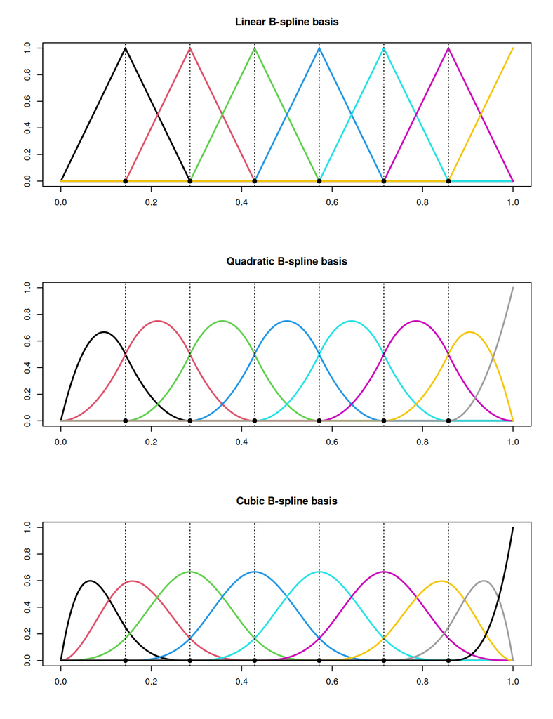

```r
splines_grid <- seq(0, 1, by=0.001)

lin_spline <- bs(splines_grid, df=7, degree = 1)
quad_spline <- bs(splines_grid, df=8, degree = 2)
cub_spline <- bs(splines_grid, df=9, degree = 3)

knots_splines <- attributes(lin_spline)$knots

par(mfrow=c(3,1))
plot(lin_spline[,1]~splines_grid, ylim=c(0,max(lin_spline)), type='l', lwd=2, col=1,
     xlab="", ylab="", main="Linear B-spline basis")
for (j in 2:ncol(lin_spline)) lines(lin_spline[,j]~splines_grid, lwd=2, col=j)

points(knots_splines,rep(0,length(knots_splines)),pch=19)
abline(v = knots_splines,lty=3)

plot(quad_spline[,1]~splines_grid, ylim=c(0,max(quad_spline)), type='l', lwd=2, col=1,
     xlab="", ylab="", main="Quadratic B-spline basis")
for (j in 2:ncol(quad_spline)) lines(quad_spline[,j]~splines_grid, lwd=2, col=j)
points(knots_splines,rep(0,length(knots_splines)),pch=19)
abline(v = knots_splines,lty=3)


plot(cub_spline[,1]~splines_grid, ylim=c(0,max(cub_spline)), type='l', lwd=2, col=1,
     xlab="", ylab="", main="Cubic B-spline basis")
for (j in 2:ncol(cub_spline)) lines(cub_spline[,j]~splines_grid, lwd=2, col=j)
points(knots_splines,rep(0,length(knots_splines)),pch=19)
abline(v = knots_splines,lty=3)
```

Notice that, by employing the user-friendly truncated power basis,

$$\begin{aligned}
h_{j}(X) &=X^{j-1}, j=1, \ldots, M \\
h_{M+\ell}(X) &=\left(X-\xi_{\ell}\right)_{+}^{M-1}, \ell=1, \ldots,
K
\end{aligned}$$

where M denotes the order of the spline, $\xi_{\ell}$ the $l$-th knot and $\left(A\right)_{+}=\max(A, 0)$, we can actually hard code the same model as `model_cubic_splines_2`

```r
# Define trunc power basis
M <- 4 # cubic spline
X_powers <- poly(Prestige$income,degree = (M-1),raw = TRUE)
X_trunc_powers <- sapply(knots, function(k) (Prestige$income-k)^(M-1)*(Prestige$income>k))
X_manual_cubic_splines <- cbind(X_powers, X_trunc_powers)

# Fit the model with OLS
model_cubic_splines_2_manual <- lm(Prestige$prestige ~ X_manual_cubic_splines)

# Construct the new_data_manual object
new_data_manual_powers <- poly(new_data[,1],degree = 3,raw = TRUE)
new_data_manual_trunc_powers <- sapply(knots, function(k) (new_data[,1]-k)^3*(new_data[,1]>k))
new_data_manual <- cbind(new_data_manual_powers, new_data_manual_trunc_powers)

# Make predictions

preds_manual_cubic_splines <- c(cbind(1,new_data_manual)%*%model_cubic_splines_2_manual$coefficients)

# Compare with the previous solution
all(dplyr::near(preds$fit,preds_manual_cubic_splines))
```

```
## [1] TRUE
```

Apart from the considerable coding effort with respect to using the built-in `bs()` function, values in the coefficients vector and in the design matrix get absurdly low and high in our hard-coded solution… Let us stick with B-spline bases from now on!

How to avoid weird behavior at the boundaries of the domain? We can employ **natural splines**.

**Recall**:

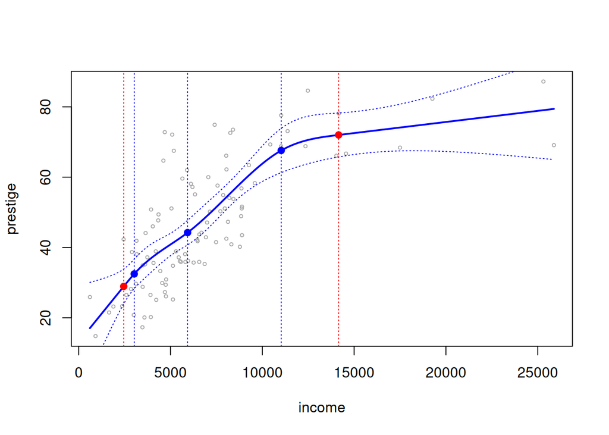

```r
knots <- quantile(Prestige$income,probs=c(0.1,0.5,0.9))
boundary_knots <- quantile(Prestige$income,probs=c(0.05,0.95))

model_ns=lm(prestige ~ ns(income,knots=knots,Boundary.knots=boundary_knots), data=Prestige) #defaults to three knots
preds=predict(model_ns, new_data,se=T)
se.bands=cbind(preds$fit +2* preds$se.fit ,preds$fit -2* preds$se.fit)

with(Prestige, plot(income ,prestige ,xlim=range(new_data$income) ,cex =.5, col =" darkgrey " ))
lines(new_data$income,preds$fit ,lwd =2, col =" blue")
matlines(new_data$income, se.bands ,lwd =1, col =" blue",lty =3)

knots_pred=predict(model_ns,list(income=knots))
points(knots,knots_pred, col='blue',pch=19)
boundary_pred <- predict(model_ns,list(income=boundary_knots))
points(boundary_knots,boundary_pred,col='red',pch=19)
abline(v = knots, lty=3, col="blue")
abline(v = boundary_knots, lty=3, col="red")
```

Clearly, the specification of knots can be non-quantile driven in general.

### Exercise

Play around with the splines functions, applying them to the Wage dataset.

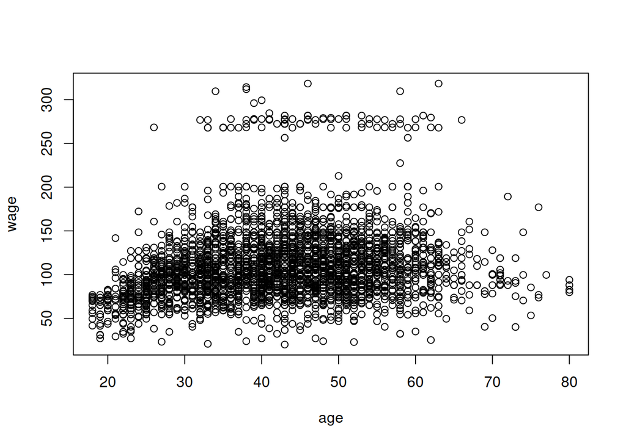

```r
data(Wage)
with(Wage, plot(age,wage))
```

## Smoothing splines

With smoothing splines we look for a function $f(\cdot)$ that makes $RSS=\sum_{i=1}^n(y_i-f(x_i))^2$ small, but that is also smooth. That is, we aim at minimizing

$$\begin{equation}
\operatorname{RSS}(f,
\lambda)=\sum_{i=1}^{n}\left\{y_{i}-f\left(x_{i}\right)\right\}^{2}+\lambda
\int\left\{f^{\prime \prime}(t)\right\}^{2} d t
\end{equation}$$

This is operationally done by performing a penalized regression over the natural spline basis, placing knots at all the inputs. This means that, remarkably, the problem defined on an infinite-dimensional function space has a finite-dimensional, unique minimizer which is a natural cubic spline! This result is not even difficult to prove (see Theorem 2.3 of Nonparametric Regression and Generalized Linear Models: A Roughness Penalty Approach by Green and Silverman) This is automatically performed in R through the `smooth.spline` function.

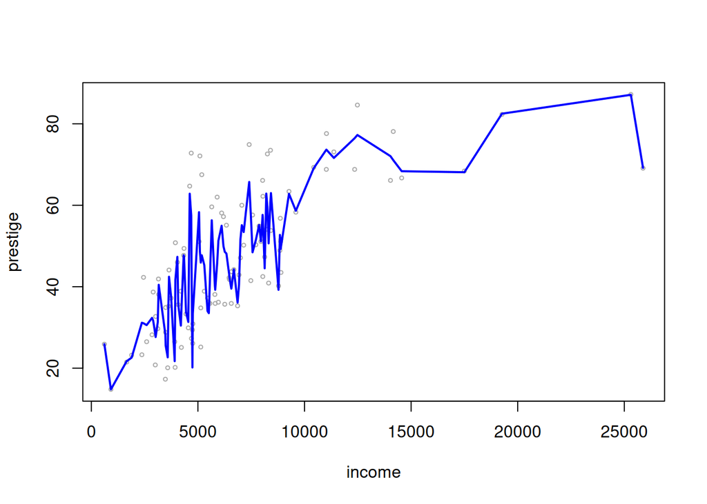

```r
fit_smooth_spline <- with(Prestige, smooth.spline(income,prestige,df=100))
with(Prestige, plot(income ,prestige, cex =.5, col =" darkgrey "))
lines(fit_smooth_spline,col="blue",lwd=2)
```

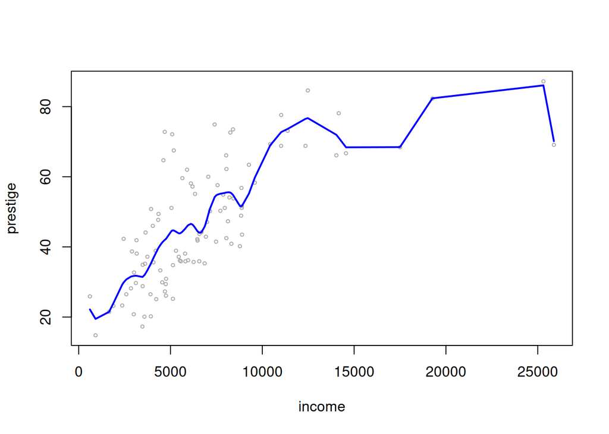

```r
fit_smooth_spline <- with(Prestige, smooth.spline(income,prestige,df=20))
with(Prestige, plot(income ,prestige, cex =.5, col =" darkgrey "))
lines(fit_smooth_spline,col="blue",lwd=2)
```

Or we can directly specify the value of the smoothing parameter $\lambda$

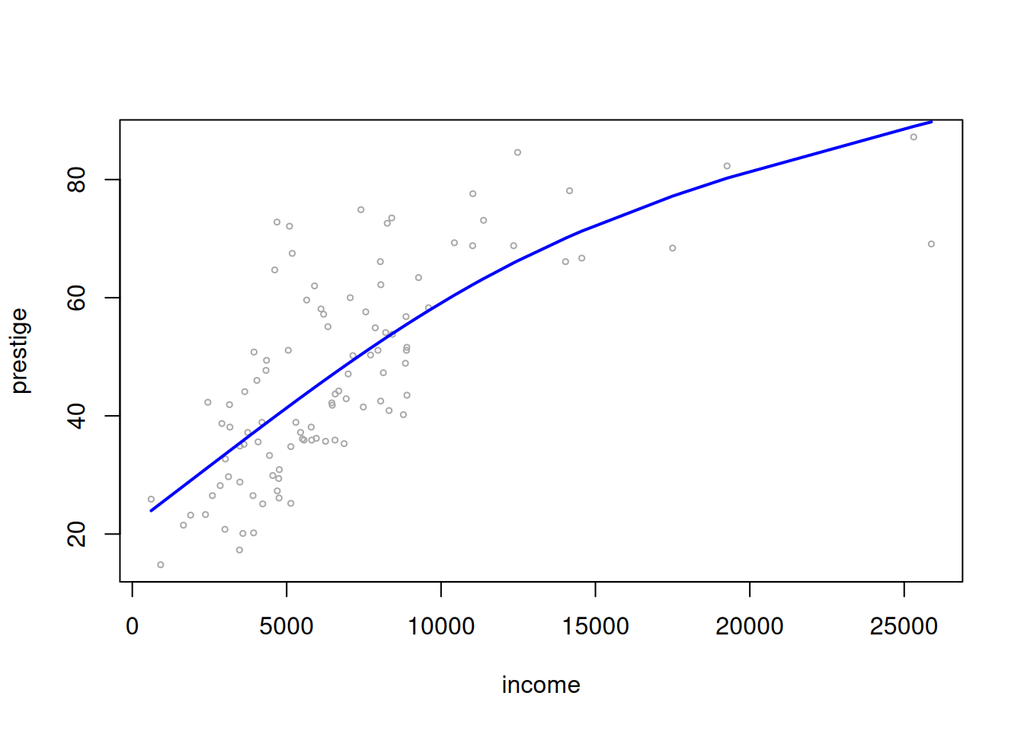

```r
fit_smooth_spline <- with(Prestige, smooth.spline(income,prestige,lambda = 1e-1))
with(Prestige, plot(income ,prestige, cex =.5, col =" darkgrey "))
lines(fit_smooth_spline,col="blue",lwd=2)
```

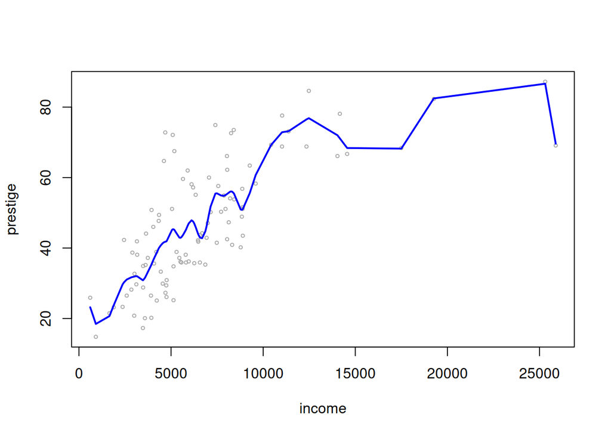

```r
fit_smooth_spline <- with(Prestige, smooth.spline(income,prestige,lambda = 1e-6))
with(Prestige, plot(income ,prestige, cex =.5, col =" darkgrey "))
lines(fit_smooth_spline,col="blue",lwd=2)
```

Generally, one wants to optimize the LOOCV error

$$\begin{equation}
\mathcal{V}_{o}=\frac{1}{n}
\sum_{i=1}^{n}\left(\hat{f}_{i}^{[-i]}-y_{i}\right)^{2}=\frac{1}{n}
\sum_{i=1}^{n}\left(y_{i}-\hat{f}_{i}\right)^{2} /\left(1-A_{i
i}\right)^{2}
\end{equation}$$

or the GCV error

$$\begin{equation}
\mathcal{V}_{g}=\frac{n
\sum_{i=1}^{n}\left(y_{i}-\hat{f}_{i}\right)^{2}}{[n-\operatorname{tr}(\mathbf{A})]^{2}}
\end{equation}$$

where $\boldsymbol{A}$ is the hat matrix of the associated regression problem (see e.g., Section 5.4.1 of The Elements of Statistical Learning by Hastie, Tibshirani and Friedman for further explanation).

```r
fit_smooth_spline_CV <- with(Prestige, smooth.spline(income,prestige,cv = TRUE))
```

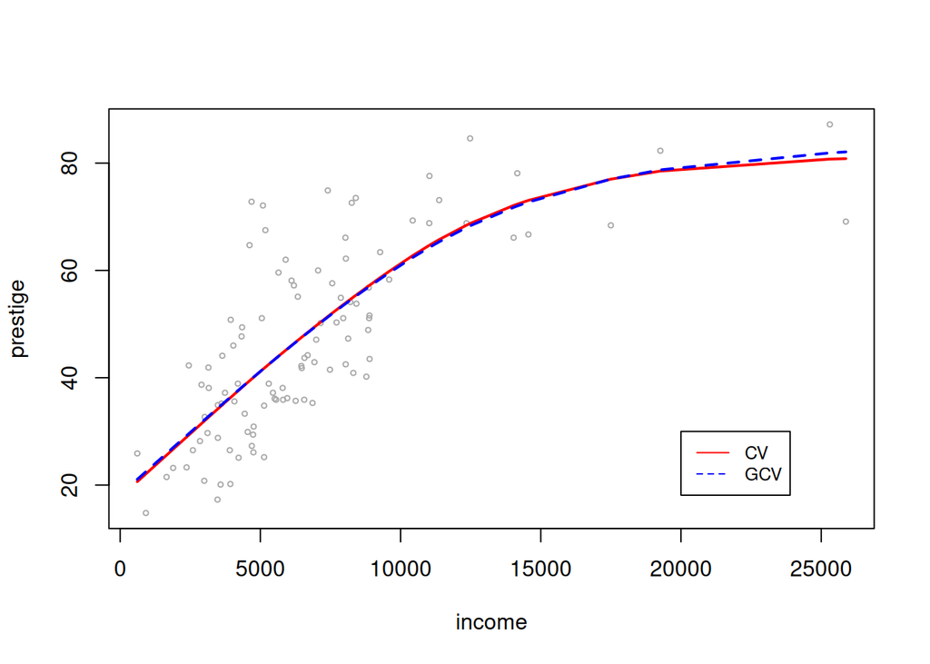

```r
fit_smooth_spline_GCV <- with(Prestige, smooth.spline(income,prestige,cv = FALSE))
with(Prestige, plot(income ,prestige, cex =.5, col =" darkgrey "))
lines(fit_smooth_spline_CV,col="red",lwd=2,lty=1)
lines(fit_smooth_spline_GCV,col="blue",lwd=2, lty=2)
legend(20000, 30, legend=c("CV", "GCV"),
       col=c("red", "blue"), lty=1:2, cex=0.8)
```

Likewise for the previous methods, it is very easy to produce forecasts

```r
predict(fit_smooth_spline_GCV,22000)
```

```
## $x
## [1] 22000
##
## $y
## [1] 80.55615
```